# MENU DO MCDONALD'S

```
                                                                            Feito por Amanda Venturin e Levi Fernandes
```

## INTRODUÇÃO

### O que é o PCA?

A Análise de Componentes Principais (ACP) ou Principal Component Analysis (PCA) é um procedimento matemático que utiliza uma transformação ortogonal (ortogonalização de vetores) para converter um conjunto de observações de variáveis possivelmente correlacionadas num conjunto de valores de variáveis linearmente não correlacionadas chamadas de componentes principais.

### Pra que serve o PCA?

Ao aplicar esse procedimento, é possível reduzir o número de variáveis a somente aquelas que tem grande importância naquele conjunto de dados. Isso é um metodo muito usado para análise e tratamento dos dados, pois com esse subconjunto é possível chegar às mesmas conclusões que com o conjunto inteiro mas com menos esforço. O PCA tem sido muito utilizado nas criações de modelos de predições em Machine Learning (ML), principalmente porque diminui o custo do processamento dos dados.

## APLICANDO O PCA

### Criação do DataFrame

Primeiro iremos criar um data frame a partir dos nossos dados, contendo apenas os dados numéricos para posteriormente analisarmos a matriz de correlação desses dados.

```python
import pandas as pd
import numpy as np
from numpy.linalg import eig
from sklearn.preprocessing import StandardScaler
import matplotlib.pyplot as plt
import seaborn as sns
%matplotlib inline
import io
from google.colab import files

uploaded = files.upload()

file_name = "menu.csv"


df = pd.read_csv(io.BytesIO(uploaded['menu.csv']))

df_numerico = pd.read_csv(io.BytesIO(uploaded['menu.csv']))

#deixando apenas colunas numericas

df_numerico.drop(["Category", "Item", "Serving Size"], axis = 1, inplace = True)

#criando o label do gráfico final

y = df[['Category']]

df_numerico.head()
```

Upload widget is only available when the cell has been executed in the current browser session. Please rerun this cell to enable.

```
Saving menu.csv to menu.csv
```

|  | Calories | Calories from Fat | Total Fat | Total Fat (% Daily Value) | Saturated Fat | Saturated Fat (% Daily Value) | Trans Fat | Cholesterol | Cholesterol (% Daily Value) | Sodium | Sodium (% Daily Value) | Carbohydrates | Carbohydrates (% Daily Value) | Dietary Fiber | Dietary Fiber (% Daily Value) | Sugars | Protein | Vitamin A (% Daily Value) | Vitamin C (% Daily Value) | Calcium (% Daily Value) | Iron (% Daily Value) |
| --- | --- | --- | --- | --- | --- | --- | --- | --- | --- | --- | --- | --- | --- | --- | --- | --- | --- | --- | --- | --- | --- |
| 0 | 300 | 120 | 13.0 | 20 | 5.0 | 25 | 0.0 | 260 | 87 | 750 | 31 | 31 | 10 | 4 | 17 | 3 | 17 | 10 | 0 | 25 | 15 |
| 1 | 250 | 70 | 8.0 | 12 | 3.0 | 15 | 0.0 | 25 | 8 | 770 | 32 | 30 | 10 | 4 | 17 | 3 | 18 | 6 | 0 | 25 | 8 |
| 2 | 370 | 200 | 23.0 | 35 | 8.0 | 42 | 0.0 | 45 | 15 | 780 | 33 | 29 | 10 | 4 | 17 | 2 | 14 | 8 | 0 | 25 | 10 |
| 3 | 450 | 250 | 28.0 | 43 | 10.0 | 52 | 0.0 | 285 | 95 | 860 | 36 | 30 | 10 | 4 | 17 | 2 | 21 | 15 | 0 | 30 | 15 |
| 4 | 400 | 210 | 23.0 | 35 | 8.0 | 42 | 0.0 | 50 | 16 | 880 | 37 | 30 | 10 | 4 | 17 | 2 | 21 | 6 | 0 | 25 | 10 |

### Matriz de Correlação

Analisaremos a matriz de correlação dos dados.

```python
matriz_correlacao = df_numerico.corr()
print(matriz_correlacao)
```

```
                               Calories  ...  Iron (% Daily Value)
Calories                       1.000000  ...              0.643552
Calories from Fat              0.904588  ...              0.735894
Total Fat                      0.904409  ...              0.734685
Total Fat (% Daily Value)      0.904123  ...              0.735478
Saturated Fat                  0.845564  ...              0.578062
Saturated Fat (% Daily Value)  0.847631  ...              0.580488
Trans Fat                      0.522441  ...              0.325476
Cholesterol                    0.596399  ...              0.655000
Cholesterol (% Daily Value)    0.595208  ...              0.653167
Sodium                         0.712309  ...              0.871593
Sodium (% Daily Value)         0.713415  ...              0.870742
Carbohydrates                  0.781539  ...              0.210241
Carbohydrates (% Daily Value)  0.781242  ...              0.210643
Dietary Fiber                  0.538894  ...              0.740411
Dietary Fiber (% Daily Value)  0.540014  ...              0.737814
Sugars                         0.259598  ...             -0.364767
Protein                        0.787847  ...              0.792719
Vitamin A (% Daily Value)      0.108844  ...              0.137879
Vitamin C (% Daily Value)     -0.068747  ...              0.001292
Calcium (% Daily Value)        0.428426  ...              0.034149
Iron (% Daily Value)           0.643552  ...              1.000000

[21 rows x 21 columns]
```

### Autovalores e Autovetores

Após isso, iremos calcular os autovalores e autovetores da matriz de correlação e ordenar os autovalores em ordem decrescente para selecionarmos os maiores autovalores correspondentes.

```python
values,vectors = eig(matriz_correlacao)
indice_ordem_values = values.argsort()

print("Autovalores: ")
print(values)
print("Autovetores: ")
print(vectors)
```

[output not shown]

### Projetando os dados nos componentes principais

Depois de acharmos os dois maiores autovalores e seus autovetores, vamos projetar os dados nos eixos x e y correspondentes aos componentes principais

```python
#Normalizando os dados

x_std = StandardScaler().fit_transform(df_numerico)

#Projetando valores no eixo x e y

projected_x = x_std.dot(vectors.T[indice_ordem_values[20]])

projected_y = x_std.dot(vectors.T[indice_ordem_values[19]])
```

### DataFrame dos os componentes principais

Após projetar os dados nos eixos, para facilitar a visualização iremos criar um data frame com os dados e em seguida plotar o gráfico correspondente.

```python
#data frame com pc1 e pc2

result =pd.DataFrame(projected_x, columns = ['PC1'])
result['PC2'] = projected_y
result['Category'] = y

result.head()
```

|  | PC1 | PC2 | Category |
| --- | --- | --- | --- |
| 0 | 1.757486 | -2.303469 | Breakfast |
| 1 | -0.212560 | -1.947947 | Breakfast |
| 2 | 1.420793 | -1.740293 | Breakfast |
| 3 | 3.692943 | -2.066588 | Breakfast |
| 4 | 1.750009 | -1.835332 | Breakfast |

### Gráfico das componentes principais

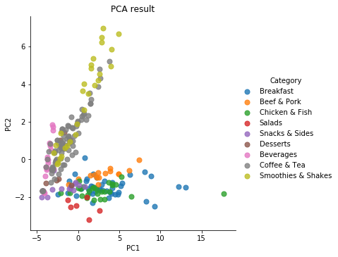

```python
#plotando o gráfico

sns.lmplot('PC1', 'PC2', data=result, fit_reg=False,  # x-axis, y-axis, data, no line
           scatter_kws={"s": 50}, # marker size
           hue="Category") # color

# title
plt.title('PCA result')
```

### Loadings

Podemos fazer um gráfico de calor para ver como os recursos se misturaram para criar os componentes.

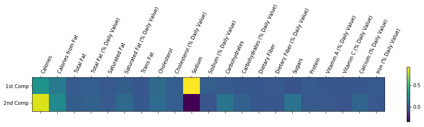

```python
from numpy import array
from sklearn.decomposition import PCA

pca = PCA(2)
B= pca.fit(df_numerico)


plt.matshow(pca.components_,cmap='viridis')
plt.yticks([0,1],['1st Comp','2nd Comp'],fontsize=10)
plt.colorbar()
plt.xticks(range(21),df_numerico,rotation=65,ha='left')
plt.tight_layout()
plt.show()
```